# Children suffering deprivation in the world

Unicef: Building A Better World For Every Child

Cindy LAUP

2022-04-04

# Our Mission

We conducted a study **around the globe** *from 2014 to 2018* to identify and measure a number of **different indices**.

This study focuses on countries around the world where **children aged 5 years old and over are suffering from deprivation**. Access to water, nutrition, medical care, education, protection, information and the *tools necessary for survival are* **not guaranteed**.

## World Map

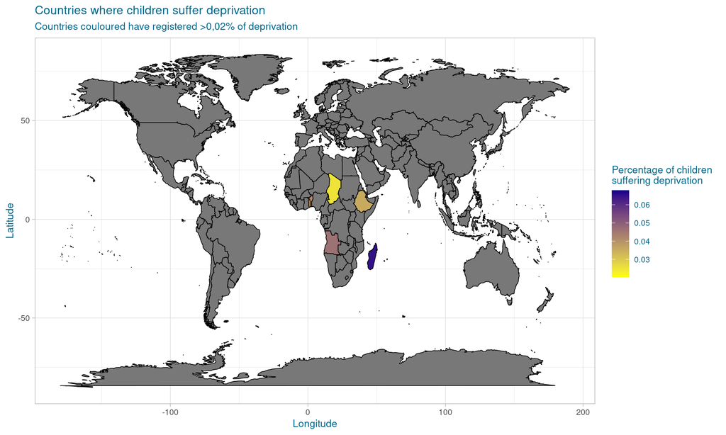

**Seven countries** around the world has registered a rate of *children aged 5 years and over are suffering from deprivation* **over 0,02%**.

- Angola
- Benin
- Chad
- Ethiopia
- Lao People’s Democratic Republic
- Madagascar
- Togo

## Seven countries

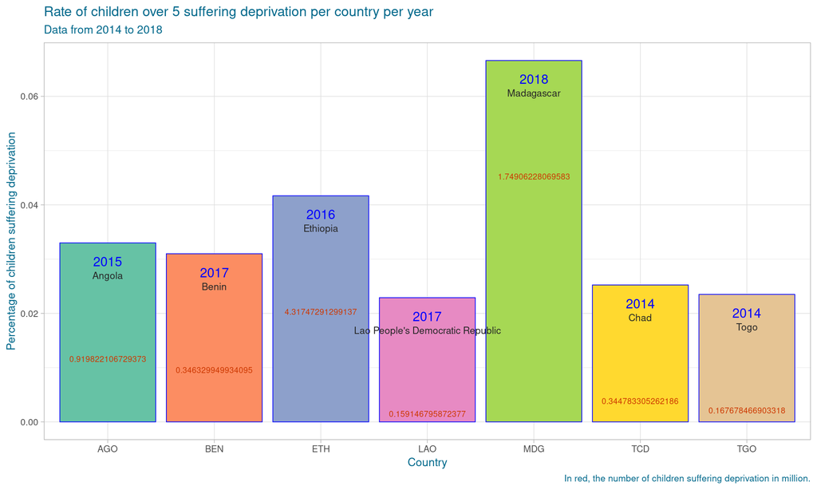

The highest child deprivation score was registered in 2018 on the **island of Madagascar**, with *0,067%* of children at risk. It is followed by **Ethiopia**, who has recorded a rate of *0,042%* in 2016. We calculated the number of children affected by deprivation (result in million). This represents *1,75 million* **children affected** in Madagascar and *4,32 million* in Ethiopia.

## Gross Domestic Product

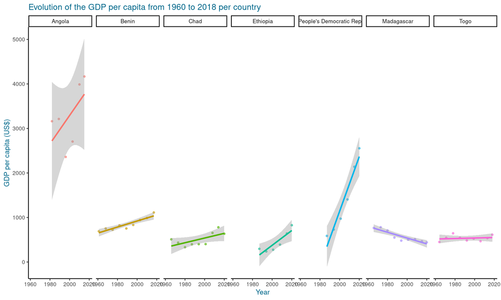

From 1960 to 2020, the Gross Domestic Product of 6 of the countries has developed positively. The calculation of the GDP is based on the assets owned by residents. However, **Madagascar has seen a significant decline** in this index over the past *60 years*. **The country’s financial situation is deteriorating**. Ethiopia’s GDP remain low and not sufficient.

## Populations

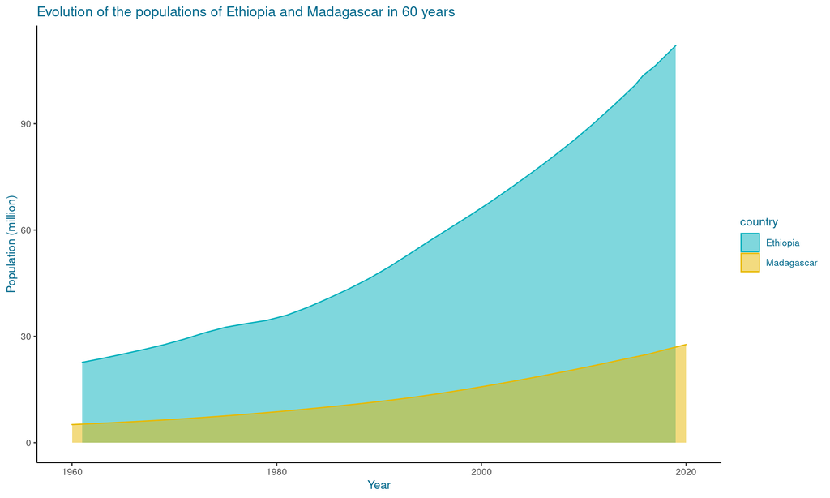

It is more than 6 million children in need for help in both countries, which represent 1/20th of their accumulated populations.

### **We must act now**. Visit the Unicef Website to take action. [*https://www.unicef.org/what-we-do*](https://www.unicef.org/what-we-do)